# Tag 5

```python
import qrcode

import numpy as np
import matplotlib.pyplot as plt
def plot(*funcs, x_min=-5, x_max=5, marker='', step=None):
    plt.grid(color='gray', linestyle='-', linewidth=1)
    xs = np.arange(x_min, x_max, step) if step else np.linspace(x_min, x_max, 50)
    for f in funcs:
        plt.plot(xs, np.vectorize(f)(xs), marker)
```

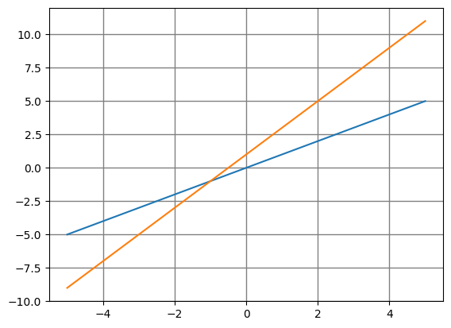

```python
plot(lambda x: x, lambda x: 2*x+1)
```

## 40

$a$ Geld des Ersten. $b$ Geld des Zweiten. $c$ Geld des Dritten. $z$ ist die Zeche. $\begin{align} a + \frac{1}{3}b &= z \\ b + \frac{1}{2}a &= z \\ c + \frac{3}{4}a &= z \\ a + b + c &= 45 \\ \\ a + \frac{1}{3}b &= b + \frac{1}{2}a | - \frac{1}{2}a - \frac{1}{3}b \\ \frac{1}{2}a &= \frac{2}{3}b | *\frac{3}{2} \\ \frac{3}{4}a &= b \\ \\ a + \frac{1}{3}b &= c + \frac{3}{4}a \\ a + \frac{1}{3}\frac{3}{4}a &= c + \frac{3}{4}a \\ a + \frac{1}{4}a &= c + \frac{3}{4}a | - \frac{3}{4}a \\ \frac{2}{4}a &= c \\ \\ a + b + c &= 45 \\ a + \frac{3}{4}a + \frac{2}{4}a &= 45 \\ \frac{9}{4}a &= 45|*\frac{4}{9} \\ a &= 20 \\ \\ \frac{3}{4}a &= b \\ \frac{3}{4}20 &= b \\ 15 &= b \\ \\ \frac{2}{4}a &= c \\ \frac{2}{4}20 &= c \\ 10 &= c \\ \\ a + \frac{1}{3}b = 20 + \frac{1}{3}*15 = 25 \end{align}$

## 6

### a)

Modellierung einer zweistelligen Zahl: $a * 10 + b = c$ mit $a, b \in \{0,1,2,3,4,5,6,7,8,9\}$.

$\begin{align} a * 10 + b + 9 &= b * 10 + a \\ a*2 &= b \\ \\ a * 10 + (a*2) + 9 &= (a*2) * 10 + a \\ \Leftrightarrow a * 10 + 2a + 9 &= 20a + a \\ \Leftrightarrow 12a + 9 &= 21a | -21a - 9 \\ \Leftrightarrow -9a &= -9 | /(-9) \\ \Leftrightarrow a &= 1 \\ \\ a*2 &= b \\ \Leftrightarrow 1*2 &= b \\ \Leftrightarrow 2 &= b \\ \end{align}$

Die Zahl ist $12$.

### b)

Bei einem Produkt ist die Reihenfolge egal. Wir nehmen an: $a > b$.

$\begin{align} a-b &= 4 |+b\\ (a-3)(b-3) &= a*b - 69 \\ \\ \Leftrightarrow a &= b + 4 \\ \Leftrightarrow ab -3a -3b + 9 &= ab - 69 | -ab \\ \\ \Leftrightarrow a &= b + 4 \\ \Leftrightarrow -3a -3b + 9 &= -69 \\ \\ -3(b + 4) -3b + 9 &= -69 \\ \Leftrightarrow -3b - 12 -3b + 9 &= -69 | + 3 \\ \Leftrightarrow -6b &= -66 | /(-6) \\ \Leftrightarrow b &= 11 \\ \\ a &= b + 4 \\ \Leftrightarrow a &= 11 + 4 \\ \Leftrightarrow a &= 15 \\ \end{align}$

## 7

$f_A(x) = 10/10 x + 10 = x + 10$

Für B ein Gleichungssystem lösen. Ansatz ist eine lineare Gleichung $m*x + n = p$

$m*40 + n = 30$

Steigung ist $m = \frac{20}{10} = 2$

Mit der ersten Gleichung $2*40 + n = 30 \Leftrightarrow n = -50$

$f_B(x) = 2x - 50$

Rechnerisch: Wann ist A besser?

$\begin{align} f_A(x) &< f_B(x) \\ x+10 &< 2x-50 | -x + 50 \\ 60 &< x \\ x &> 60 \\ \end{align}$

Für Bestellmengen über 60 ist A besser. Sonst B.

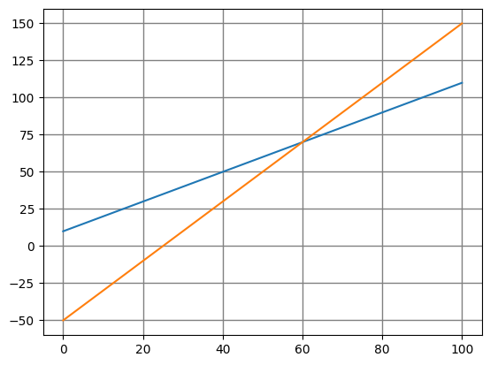

```python
plot(lambda x: x+10, lambda x: 2*x-50, x_min = 0, x_max = 100)
```

Nun für jede Menge separat berechnet. Eventuell werden mehr Chips als nötig bestellt.

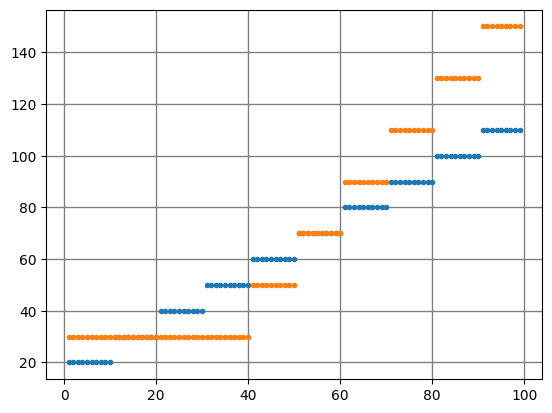

```python
def a(x):
    # Aufrunden auf nächste Zehnerstelle
    x = (x + 9) // 10 * 10
    return 10 + x / 10 * 10


def b(x):
    if x <= 40:
        return 30
    else:
        weitere = x - 40
        # Aufrunden auf nächste Zehnerstelle
        weitere = (weitere + 9) // 10 * 10
        return 30 + weitere / 10 * 20


def best(x):
    return min(a(x), b(x))

plot(a, b, #best,
     x_min=1, x_max=100, marker='.', step=1)
```

## 9

$\begin{align} x - 5y &= a \\ 3x + by &= 57 \\ \end{align}$

### a)

Für $(x; y) = (2; 1)$ einsetzen und für $a$ und $b$ lösen.

$\begin{align} (2) - 5(1) &= a \\ 3(2) + b(1) &= 57 \\ \\ \Leftrightarrow -3 &= a \\ \Leftrightarrow 6 + b &= 57 | -6\\ \\ \Leftrightarrow -3 &= a \\ \Leftrightarrow b &= 51\\ \end{align}$

### c)

Zuerst c. Für unendlich viele Lösungen (oder auch nur zwei) müssen die gleichungen die Selbe Lösungsmenge beschreiben. Daher wird so umgeformt, dass der Faktor vor $x$ gleich ist.

$\begin{align} x - 5y &= a | *3\\ 3x + by &= 57 \\ \\ \Leftrightarrow 3x - 15y &= 3a \\ \Leftrightarrow 3x + by &= 57 \\ \end{align}$

Die verbleibenden Koeffizienten werden verglichen. Es ergibt sich $b = -15$ und $a = \frac{57}{3} = 19$

### b)

Keine Lösung.

#### Variante eins

$\begin{align} x - 5y &= a | *3\\ 3x + by &= 57 \\ \\ \Leftrightarrow 3x - 15y &= 3a \\ \Leftrightarrow 3x + by &= 57 | -\\ \\ \Leftrightarrow - 15y - by &= 3a - 57 \\ \\ \Leftrightarrow (- 15 - b)y &= 3a - 57 \\ \end{align}$

Fallunterscheidung $b = -15$

$\begin{align} (- 15 - (-15))y &= 3a - 57 \\ \Leftrightarrow 0y &= 3a - 57 | + 57 \\ \Leftrightarrow 57 &= 3a | /3 \\ \Leftrightarrow 19 &= a \\ \end{align}$

Für $b = -15$ und $a \neq 19$ widersprechen sich die Gleichungen und es gibt keine Lösung.

Anderer Fall

$\begin{align} (- 15 - b)y &= 3a - 57 | /(- 15 - b) \\ \Leftrightarrow y &= \frac{3a - 57}{-15- b} \\ \end{align}$

Hier kann $y$ immer berechnet werden und das Gleichungssystem ist lösbar.

#### Variante zwei

Die Lösungsmenge einer linearen Gleichung mit zwei Unbekannten entspricht einer Geraden im zweidimensionalen Raum. Die Lösungsmenge zweier Gleichungen entspricht der Schnittmenge der einzelnen Lösungsmengen. In a) war dies ein einzelner Punkt; in c) waren sie identisch. Damit es keine Lösung gibt, dürfen sich die Geraden nicht schneiden. Sie verlaufen also in die selbe richtung. Aus der Achsenabschnitsform wissen wir, dass die Inhomogenität (die einzelne Zahl rechts) für den Abstand zum Koordinatenursprung verantwortlich ist, also parallel verschiebt. So können wir eine Parallelverschiebung erreichen. Es gilt also $b = -15$ und $a \neq 19$.

## 10

Es kommt das produkt zweier unbekannter vor, weshalb die Gleichungen nicht linear sind. Trotzdem kann durch Einsetzen der ersten in die zweite Gleichung das System gelöst werden.

$\begin{align} xy &=3+2x \\ 2xy - 8 = 3x \\ \\ \Leftrightarrow 2(3+2x) - 8 = 3x \\ \Leftrightarrow 6+4x - 8 = 3x | -3x \\ \Leftrightarrow x - 2 = 0 | + 2 \\ \Leftrightarrow x = 2 \\ \\ xy &=3+2x \\ \Leftrightarrow 2y &=3+2*2 \\ \Leftrightarrow 2y &=7|/2 \\ \Leftrightarrow y &=\frac{7}{2} \\ \end{align}$

## 3

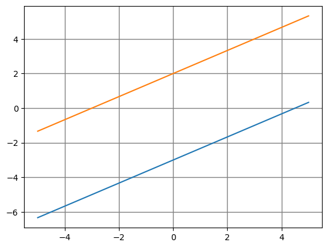

```python
plot(lambda x:2/3*x-3, lambda x:2/3*x+2)
```

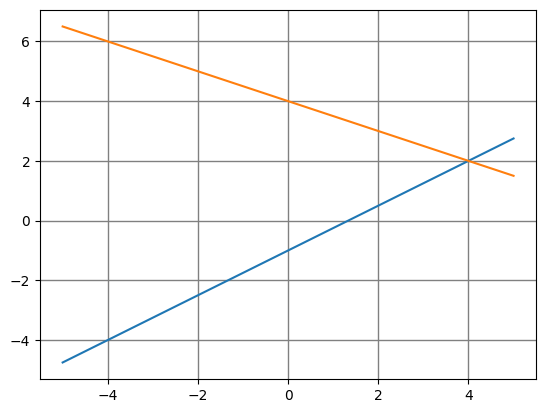

```python
plot(lambda x: 3/4*x-1, lambda x: -x/2+4)
```

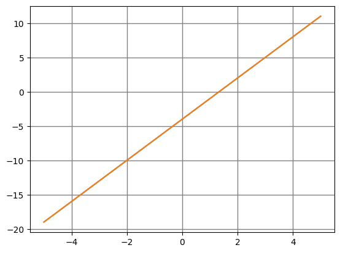

```python
plot(lambda x: -4+3*x, lambda x: -4+3*x)
```

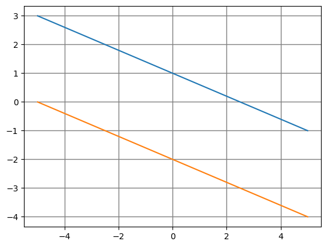

```python
plot(lambda x: -2/5*x+1, lambda x: -2/5*x - 2)
```

```
[<mpl_toolkits.mplot3d.art3d.Line3D at 0x17293097950>]
```

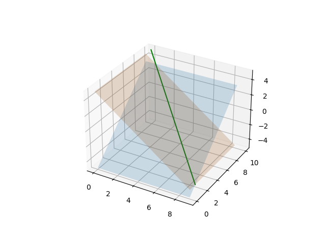

```python
%matplotlib widget
xx, yy = np.meshgrid(range(10), range(10))
fig = plt.figure()
ax = fig.add_subplot(111,projection='3d')
ax.plot_surface(xx, yy, yy-5, alpha=0.2)
ax.plot_surface(xx, yy, -xx+5, alpha=0.2)
x = np.arange(10)
ax.plot(x , 10-x, 5 - x, color='green')
```

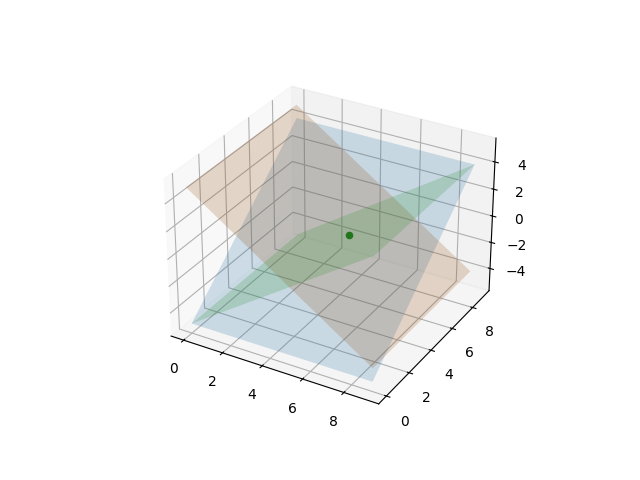

```python
fig = plt.figure()
ax = fig.add_subplot(111,projection='3d')
ax.plot_surface(xx, yy, yy-5, alpha=0.2)
ax.plot_surface(xx, yy, -xx+5, alpha=0.2)
ax.plot_surface(xx, yy, xx-5, alpha=0.2)
ax.scatter(5 , 5, 0, color='green')
```

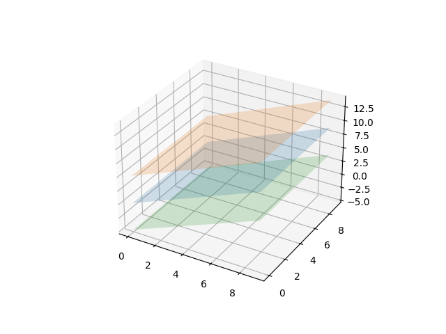

```python
fig = plt.figure()
ax = fig.add_subplot(111,projection='3d')
ax.plot_surface(xx, yy, xx, alpha=0.2)
ax.plot_surface(xx, yy, xx+5, alpha=0.2)
ax.plot_surface(xx, yy, xx-5, alpha=0.2)
```

```
[<mpl_toolkits.mplot3d.art3d.Line3D at 0x1729351ff80>]
```

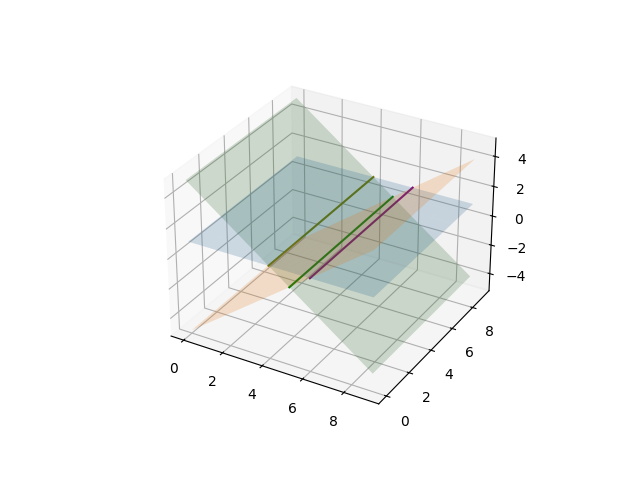

```python
fig = plt.figure()
ax = fig.add_subplot(111,projection='3d')
ax.plot_surface(xx, yy, xx*0+1, alpha=0.2)
ax.plot_surface(xx, yy, xx-5, alpha=0.2)
ax.plot_surface(xx, yy, -xx+5, alpha=0.2)
x = np.arange(10)
ax.plot(0*x+5, x, 0*x, color='green')
ax.plot(0*x+4, x, 0*x+1, color='olive')
ax.plot(0*x+6, x, 0*x+1, color='purple')
```

# 3.2 Lineare Ungleichungen

## 1

```python
-1/4 < -1/5
```

```
True
```

```python
(-4)**2 < (-5)**2 # 16 < 25
```

```
True
```

```python
(-4)**3 > (-5)**3 # -64 > -125
```

```
True
```

```python
-4**2 < (-5)**2 # -16 < 25
```

```
True
```

```python
1/(-4)**2 > 1/(-5)**3 # 1/16 > 1/-125
```

```
True
```

```python
1/(-4)**3 < 1/(-(-5)**3) # -1/64 < 1/125
```

```
True
```

## 2

### a)

a und b sind entweder beide größer als 0 oder beide kleiner als 0.

### b)

```python
%%latex
$-2c < 0 | :(-2)$ Division (oder Multiplikation) mit negativer Zahl dreht die Ungleichung um.

$c > 0$
```

$-2c < 0 | :(-2)$ Division (oder Multiplikation) mit negativer Zahl dreht die Ungleichung um. $c > 0$

### c)

Angenommen a ist 0. Dann ist keine der Ungleichungen erfüllt. a kann also nicht 0 sein.

Nun kann durch $a^2$ geteilt werden. Es ergibt sich $1 < a$ oder $ 1 > a$. a darf nicht 0 und nicht 1 sein.

```python
import sympy
from sympy.abc import a, b, c, x, y, q
```

```python
sympy.solve(a**2 < a**3) | sympy.solve(a**2 > a**3)
```

$\displaystyle \left(1 < a \wedge a < \infty\right) \vee \left(a > -\infty \wedge a < 1 \wedge a \neq 0\right)$

Als kleine Ergänzung noch die Antwort mittels der Python-Bibliothek sympy (symbolische Mathematik). Diese kommt auf das gleiche Ergebnis, hat allerdings auch das Verhalten im Unendlichen bedacht. Dieses hebt sich aber auf, da Unendlich oder negativ Unendlich je eine der Gleichung erfüllt.

## 3

### a)

$-5x+3 > -17| -3$

$-5x > -20 | :(-5)$

$x < 4$

$L_a = \{x | x \in \mathbb{R} \wedge x < 4\}$

### b)

$0.6-3x<3x-2.4 | -0.6 - 3x$

$-6x < -3|:(-6) $

$x > \frac{1}{2}$

$L_b = \{x | x \in \mathbb{R} \wedge x > \frac{1}{2}\}$

### c)

$-\frac{5}{9}x-1>-\frac{2}{3} | +1$

$-\frac{5}{9}x>\frac{1}{3} | :(-\frac{5}{9})$

$x<-\frac{3}{5}$

$L_c = \{x | x \in \mathbb{R} \wedge x <-\frac{3}{5}\}$

## 4

### a)

$30 - x > 12 | +x - 12$

$18 > x$

$L_a = \{x | x \in \mathbb{R} \wedge x < 18\}$

### b)

$12 + x < 3 | -12$

$x < -9$

$L_b = \{x | x \in \mathbb{R} \wedge x < -9\}$

## 5

Gegeben ein Rechteck mit den Seiten $a$ und $b$.

I $U = 2 *(a+b) > 20$

II $a = b + 2$

Einsetzen von II in I, sodass nur noch die Kürzere Seite $b$ in der Ungleichung vorkommt.

$2*((b+2) + b) > 20$

$2*(b+2 + b) > 20$

$2*(2b+2) > 20$

$4b+4 > 20 | -4$

$4b > 16 | :4$

$b > 4$

## 6

### a)

$(12 + a)/5 > 4 | 5$

$12 + a > 20 | -12$

$a > 8$

$L_a = \{x | x \in \mathbb{R} \wedge x > 8\}$

### b)

$(a - 11) * 7 < 42 | :7$

$a-11 < 6|+11$

$a < 17$

$L_b = \{x | x \in \mathbb{R} \wedge x < 17\}$

### c)

$(17 - 2x) * 3 \le 15 | :3$

$17 - 2x \le 5 | -17$

$- 2x \le -12 | :(-2)$

$x \ge 6$

$L_c = \{x | x \in \mathbb{R} \wedge x \ge 6\}$

## 8

### a)

$7 - a(x-2) > 4 | -4 + a(x-2)$

$3 > a(x-2)$

Falls $a = 0$ ist die Ungleichung immer erfüllt ($L = \{x | x \in \mathbb{R} \wedge a = 0\}$)

$a$ ist positive:

$\frac{3}{a} > x-2 | + 2$

$L = \{x | x \in \mathbb{R} \wedge a > 0 \wedge x < \frac{3}{a} + 2\}$

$a$ ist negativ:

$\frac{3}{a} < x-2 | + 2$

$L = \{x | x \in \mathbb{R} \wedge a < 0 \wedge x > \frac{3}{a} + 2\}$

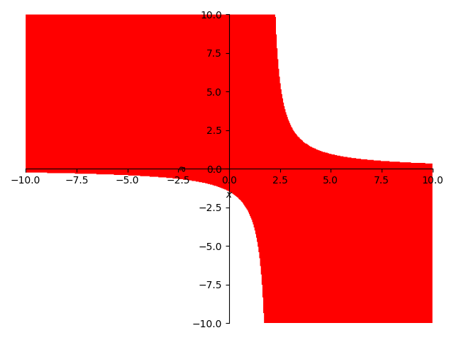

```
<sympy.plotting.backends.matplotlibbackend.matplotlib.MatplotlibBackend at 0x172937e5970>
```

```python
sympy.plot_implicit(7 - a * (x - 2) > 4, (x, -10, 10), (a, -10, 10), line_color='red')
```

### b)

$(5+q)(x-11) > 2$

Fallunterscheidungen für $q < -5$, $q = -5$ und $q > -5$:

$q < -5 \Leftrightarrow 5 + q < 0$ also negativ.

$x-11 < \frac{2}{5+q} | + 11$

$x < \frac{2}{5+q} + 11$

$L = \{x | x \in \mathbb{r} \wedge q < -5 \wedge x < \frac{2}{5+q} + 11\}$

$q = -5 \Leftrightarrow 5+q = 0$

$0*(x-11) = 0 < 2$ Die Lösungsmenge ist leer.

$q > -5 \Leftrightarrow 5 + q > 0$

$x-11 > \frac{2}{5+q} | +11$

$x > \frac{2}{5+q} + 11$

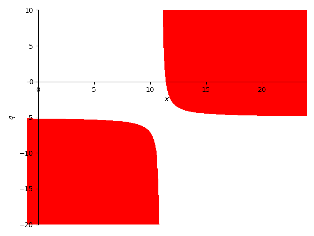

```
<sympy.plotting.backends.matplotlibbackend.matplotlib.MatplotlibBackend at 0x172957e9dc0>
```

```python
sympy.plot_implicit((5 + q) * (x - 11) > 2, (x, -1, 24), (q, -20, 10), line_color='red')
```

### c)

Lösung ergibt sich aus der von d) mit $p = 4$:

$(4-q)(x+9) < 6$

Fallunterscheidungen für $q < 4$, $q = 4$ und $q > 4$:

Fall 1 $q < 4$

$(4-q)(x+9) < 6 |:(4 - q)$

$x+9 < \frac{6}{4 - q} | -9$

$x < \frac{6}{4 - q} - 9$

$L = \{x | x \in \mathbb{r} \wedge q < 4 \wedge x < \frac{6}{4 - q} - 9\}$

Für $q = 4$ ergibt sich $0 < 6$. Die Lösungsmenge sind die Reellen Zahlen ($L = \{x | x \in \mathbb{R} \wedge a = 0\}$).

Fall 3 $q > 4$

$(4-q)(x+9) < 6 |:(4 - q)$

$x+9 > \frac{6}{4 - q} | -9$

$x > \frac{6}{4 - q} - 9$

$L = \{x | x \in \mathbb{r} \wedge q > 4 \wedge x > \frac{6}{4 - q} - 9\}$

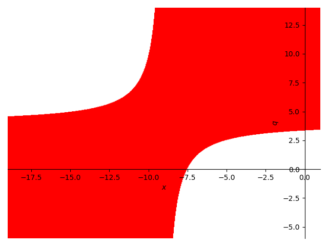

```
<sympy.plotting.backends.matplotlibbackend.matplotlib.MatplotlibBackend at 0x17295c201a0>
```

```python
sympy.plot_implicit((4 - q) * (x + 9) < 6, (x, -19, 1), (q, -6, 14), line_color='red')
```

### d)

$p = q$

$0*(x+9) = 0 < 6$

$L = \{x | x \in \mathbb{R} \wedge p = q\}$

Falls 2:

$p < q$

$x + 9 > \frac{6}{p - q} | -9$

$x > \frac{6}{p - q} -9$

$L = \{x | x \in \mathbb{R} \wedge p < q \wedge x > \frac{6}{p - q} -9\}$

Falls 3:

$p > q$

$x + 9 < \frac{6}{p - q} | -9$

$x < \frac{6}{p - q} -9$

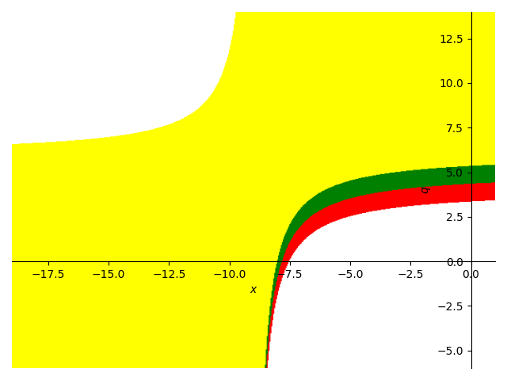

```python
plot = sympy.plot_implicit((4 - q) * (x + 9) < 6, (x, -19, 1), (q, -6, 14), show=False, line_color='red')
plot.append(sympy.plot_implicit((5 - q) * (x + 9) < 6, (x, -19, 1), (q, -6, 14), show=False, line_color='green')[0])
plot.append(sympy.plot_implicit((6 - q) * (x + 9) < 6, (x, -19, 1), (q, -6, 14), show=False, line_color='yellow')[0])
plot.show()
```

p wird veriiert (mangels 3d plot) und sorgt für eine vertikale Verschiebung.

## 9

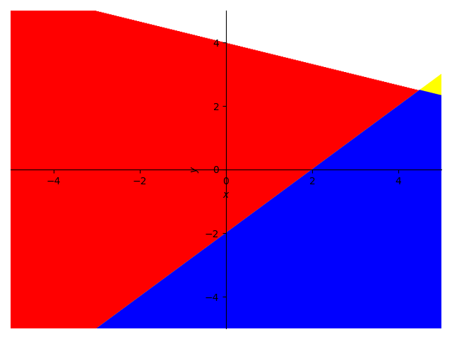

```python
f0 = x/3+y < 4
f1 = -x+y <= -2
plot = sympy.plot_implicit(f0, show=False, line_color='red')
plot.append(sympy.plot_implicit(f1, show=False, line_color='yellow')[0])
plot.append(sympy.plot_implicit(f0 & f1, show=False, line_color='blue')[0])
plot.show()
```

## 7

### a)

$(\frac{1}{3}x-1)(4x+5)\le(2x-6)(\frac{2}{3}x+\frac{2}{9})$

$\frac{4}{3}x^2-4x +\frac{5}{3}x-5 \le \frac{4}{3}x^2+\frac{4}{9}x -\frac{12}{3}x-\frac{12}{9} | - \frac{4}{3}x^2 +\frac{32}{9}x + 5$

$-\frac{36}{9}x +\frac{15}{9}x +\frac{32}{9}x\le -\frac{12}{9} + \frac{45}{9} |*9$

$-36x +15x +32x\le -12 + 45$

$11x\le 33 | /11$

$x\le 3$

### b)

$(3s + 3)(7s + 7) < 21s^+105$

$21s^2+21s+21s+21 < 21s^2+105 | -21s^2 - 21$

$42s < 84 | /42$

$s < 2$

### c)

$(t-7)^2 <(t+3)(t-3)+2$

$t^2 - 14t + 49 < t^2 -3^2 +2 | -t^2 - 49$

$-14t < -56 |/(-14)$

$t > 4$

### d)

$(1-4v)(1+4v) \ge(3+2v)(1-8v)+20$

$1 - 16v^2 \ge 3 -24v +2v -16v^2+20 |+16v^2 - 23$

$-22 \ge -22v | /(-22)$

$1 \le v$